# TsangStreamLab Data

Yu-Fen Huang

12 January, 2022 07:15

# Intro

This webpage is built for vidualizing the stream and rainfall data that set up by [Tsang Stream Lab](https://tsangstreamlab.org/) in [the Department of Natural Resources and Environmental Management, Univerisyt of Hawaii at Manoa](https://cms.ctahr.hawaii.edu/nrem/). The McCrometer stations are funded by [UH-CTAHR](https://cms.ctahr.hawaii.edu/). *Note: We’re still working on letting user download data from this website, but plese contact us for the data.* Note: please be awared that the data showing here did not have quality control yet*

# TsangStreamLab Map

[interactive chart not shown]

# Live Streamming Data

## [Stream] Poamoho

Poamoho stream is located in the central Oahu, and the water flows from the top of Koolau Ridge flows into Tanada Reservoir. We appriciate [DOFAW](http://dlnr.hawaii.gov/dofaw/)’s support to monitor the Poamoho stream.

Poamoho stream gage has been built in March, 2018. Stream stage and rainfall is measured in this site by using [McCrometer mini field station](https://www.mccrometer.com/asset-get.download.jsa?id=52003822855) with Iradium satellite telemetry.

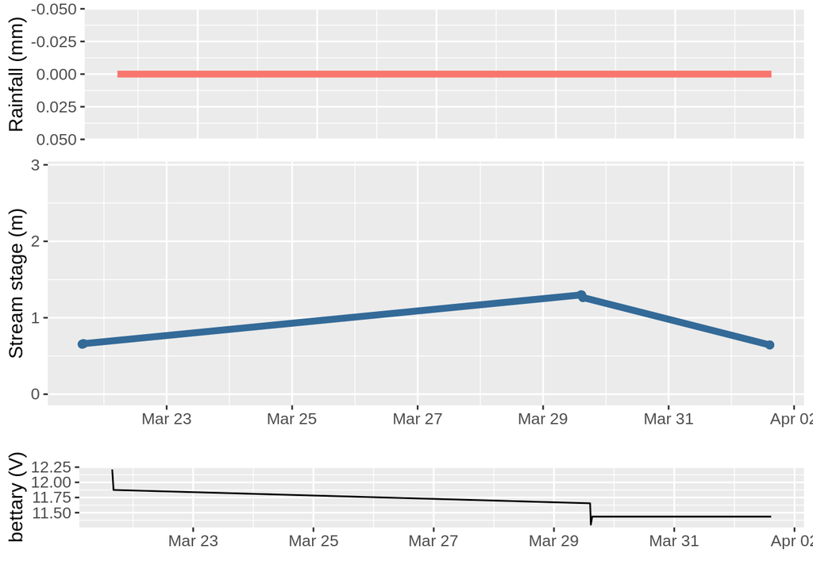

## [Weather] Lyon Greenhouse Weather Station This staion started in Febuary 2018. With Campball Scientific data logger CR3000 and their sensors at [Lyon Arboretum](https://manoa.hawaii.edu/lyonarboretum/). We’re measuring precipitation, air temperature, solar radiation, winds, humidity, soil moisture, and soil temperature.

[Lyon Arboretum](https://manoa.hawaii.edu/lyonarboretum/) is located in Manoa Valley. The stream, Aihualama, flows through Lyon Arboretum. Aihualama is the first order stream (head stream), and it’s the upstream of Manoa stream that flows into Ala Wai Canal. Besides, the coverage here is mostly forest that is an appropriate place to understand the hydrology in a natural watershed. We really appriciate Lyon Arboretum providing their place for us to setting up some real-time stream and weather stations. Besides, there is high annual rainfall at Lyon Arboretrum.

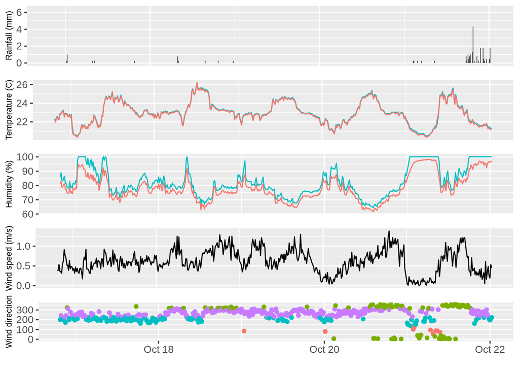

## [Stream] Kaluanui

This stream gage has been built in Dec 2020 for sediment and stream flow measurement by using [McCrometer mini field station](https://www.mccrometer.com/asset-get.download.jsa?id=52003822855) with Iradium satellite telemetry.